# Regresi Linear

Analisis regresi adalah metode yang biasa digunakan untuk mengevaluasi hubungan antara satu peubah dengan peubah lainnya atau satu peubah dengan beberapa peubah lainnya. Analisis ini merupakan salah satu metode statistik yang banyak digunakan karena memberikan metode yang sederhana untuk menetapkan hubungan fungsional diantara beberapa peubah. Analisis regresi yang sering digunakan adalah regresi linear. Dalam perkembangannya, terdapat dua macam analisis regresi linear yang digunakan, yaitu analisis regresi linear sederhana dan analisis regresi linear berganda. Pada model regresi linear sederhana, hanya melibatkan satu peubah respon dan satu peubah penjelas, sedangkan pada analisis regresi linear berganda melibatkan lebih dari satu peubah penjelas.  
library yang diperlukan dalam analisis ini yaitu:

```r
library(olsrr)
library(MASS)
library(lmtest)
library(car)
```

# Import data dari file csv ke R

Data yang digunakan adalah data sekunder yang diambil dari BPS tentang produksi padi di Indonesia tahun 2010. Data meliputi produksi padi di Indonesia (Y_1) dengan satuan ton, luas lahan di tiap provinsi (X_1) dengan satuan hektar, Produktivitas (X_2) dengan satuan kuintal per hektar, nilai tukar petani di tiap provinsi (X_3) dengan satuan persen, dan jumlah penduduk tiap provinsi (X_4).

```r
data<- read.csv("D:/Job/E learning/Regression Tree/elearning/padi2.csv",header=T)
str(data)
```

```
## 'data.frame':    33 obs. of  5 variables:
##  $ produksi.padi: int  1582393 3582302 2211248 574864 628828 3272451 516869 2807676 22259 1246 ...
##  $ luas.lahan   : int  313649 468724 229693 115961 112434 611386 92976 345437 4056 442 ...
##  $ produktivitas: num  44.9 47.5 48 36.8 40.9 ...
##  $ NTP          : num  106.8 98.5 98.1 110.5 98.1 ...
##  $ Penduduk     : int  4494410 12982204 4846909 5538367 3092265 7450394 1715518 7608405 1223296 1679163 ...
```

Adapun tahapan dalam analisis regresi linear adalah sebagai berikut:  
1. Pendugaan Persamaan Regresi  
2. Pengujian Parameter  
3. Pemeriksaan asumsi  
4. Penanganan asumsi  
5. Pemeriksaan pencilan dan Amatan Berpengaruh

# Pendugaan Persamaan Regresi

```r
model<- lm(produksi.padi ~ luas.lahan+produktivitas+NTP+Penduduk, data = data)
summary(model)
```

```
##
## Call:
## lm(formula = produksi.padi ~ luas.lahan + produktivitas + NTP +
##     Penduduk, data = data)
##
## Residuals:
##      Min       1Q   Median       3Q      Max
## -1245677  -203974    47967   275528   573175
##
## Coefficients:
##                 Estimate Std. Error t value Pr(>|t|)
## (Intercept)    2.148e+05  7.404e+05   0.290   0.7739
## luas.lahan     5.415e+00  5.493e-01   9.859 1.32e-10 ***
## produktivitas  1.610e+04  9.424e+03   1.709   0.0986 .
## NTP           -1.355e+04  7.288e+03  -1.859   0.0736 .
## Penduduk       1.517e-01  1.666e-02   9.107 7.27e-10 ***
## ---
## Signif. codes:  0 '***' 0.001 '**' 0.01 '*' 0.05 '.' 0.1 ' ' 1
##
## Residual standard error: 400500 on 28 degrees of freedom
## Multiple R-squared:  0.9858, Adjusted R-squared:  0.9838
## F-statistic: 487.7 on 4 and 28 DF,  p-value: < 2.2e-16
```

# Pengujian Parameter

1. Uji-t  
   Uji-t dimaksudkan untuk menguji pengaruh setiap peubah penjelas secara satu per satu terhadap peubah responnya.

Coefficients: Estimate Std. Error t value Pr(>|t|)  
(Intercept) 2.148e+05 7.404e+05 0.290 0.7739  
luas.lahan 5.415e+00 5.493e-01 9.859 1.32e-10 produktivitas 1.610e+04 9.424e+03 1.709 0.0986  
NTP -1.355e+04 7.288e+03 -1.859 0.0736  
Penduduk 1.517e-01 1.666e-02 9.107 7.27e-10

Berdasarkan output diatas, peubah produktivitas dan NTP mempunyai p-value lebih besar dari $\alpha=0.05$ sehingga nilai tukar petani dan produktivitas tidak memiliki hubungan linear dengan produksi padi.

2. Uji-F  
   Uji-F dimaksudkan untuk mengetahui peubah-peubah penjelas yang ada dalam model berpengaruh secara serempak terhadap respon atau tidak.

F-statistic: 487.7 on 4 and 28 DF, p-value: < 2.2e-16

Berdasarkan output diatas, p-value lebih kecil dari $\alpha=0.05$ sehingga produksi padi mempunyai hubungan linear dengan minimal satu peubah penjelas.

# Regresi Bertatar (Stepwise Regression)

Prosedur regresi bertatar (stepwise regression)merupakan prosedur statistik untuk menentukan peubah mana yang akan dimasukkan ke dalam persamaan regresi. Prosedur ini pada dasarnya merupakan kombinasi dari prosedur eliminasi langkah mundur (backward regression) dan prosedur eliminasi langkah maju (forward regression).

```r
model<- lm(produksi.padi ~ luas.lahan+produktivitas+NTP+Penduduk, data = data)
ols_step_both_p(model)
```

```
## Stepwise Selection Method
## ---------------------------
##
## Candidate Terms:
##
## 1. luas.lahan
## 2. produktivitas
## 3. NTP
## 4. Penduduk
##
## We are selecting variables based on p value...
##
## Variables Entered/Removed:
##
## - Penduduk added
## - luas.lahan added
##
## No more variables to be added/removed.
##
##
## Final Model Output
## ------------------
##
##                              Model Summary
## ------------------------------------------------------------------------
## R                       0.992       RMSE                     423048.926
## R-Squared               0.983       Coef. Var                    21.003
## Adj. R-Squared          0.982       MSE                178970393873.685
## Pred R-Squared          0.978       MAE                      329938.841
## ------------------------------------------------------------------------
##  RMSE: Root Mean Square Error
##  MSE: Mean Square Error
##  MAE: Mean Absolute Error
##
##                                     ANOVA
## ------------------------------------------------------------------------------
##                     Sum of
##                    Squares        DF         Mean Square       F         Sig.
## ------------------------------------------------------------------------------
## Regression    3.120665e+14         2        1.560333e+14    871.838    0.0000
## Residual      5.369112e+12        30    178970393873.685
## Total         3.174356e+14        32
## ------------------------------------------------------------------------------
##
##                                           Parameter Estimates
## -------------------------------------------------------------------------------------------------------
##       model           Beta    Std. Error    Std. Beta      t        Sig           lower          upper
## -------------------------------------------------------------------------------------------------------
## (Intercept)    -417860.530     96000.907                 -4.353    0.000    -613920.537    -221800.522
##    Penduduk          0.171         0.015        0.558    11.176    0.000          0.140          0.202
##  luas.lahan          4.956         0.533        0.464     9.292    0.000          3.867          6.045
## -------------------------------------------------------------------------------------------------------
```

```
##
##                                  Stepwise Selection Summary
## ---------------------------------------------------------------------------------------------
##                        Added/                   Adj.
## Step     Variable     Removed     R-Square    R-Square      C(p)        AIC          RMSE
## ---------------------------------------------------------------------------------------------
##    1     Penduduk     addition       0.934       0.932    100.7990    996.2786    819576.4735
##    2    luas.lahan    addition       0.983       0.982      6.4680    953.5508    423048.9261
## ---------------------------------------------------------------------------------------------
```

Berdasarkan output diatas, Persamaan regresi terbaik yang diperoleh adalah dengan mengeliminasi peubah nilai tukar petani dan peubah produktivitas petani. Sehingga persamaan regresi yang diperoleh  
Y =-417860.530 + 0.171 Jumlah Penduduk + 4.956 Luas Lahan

# Pemeriksaan Asumsi

### 1. Mendeteksi sisaan Menyebar Normal

Dalam mendeteksi sisaan menyebar normal dapat dilakukan dengan cara eksplorasi dan uji formal

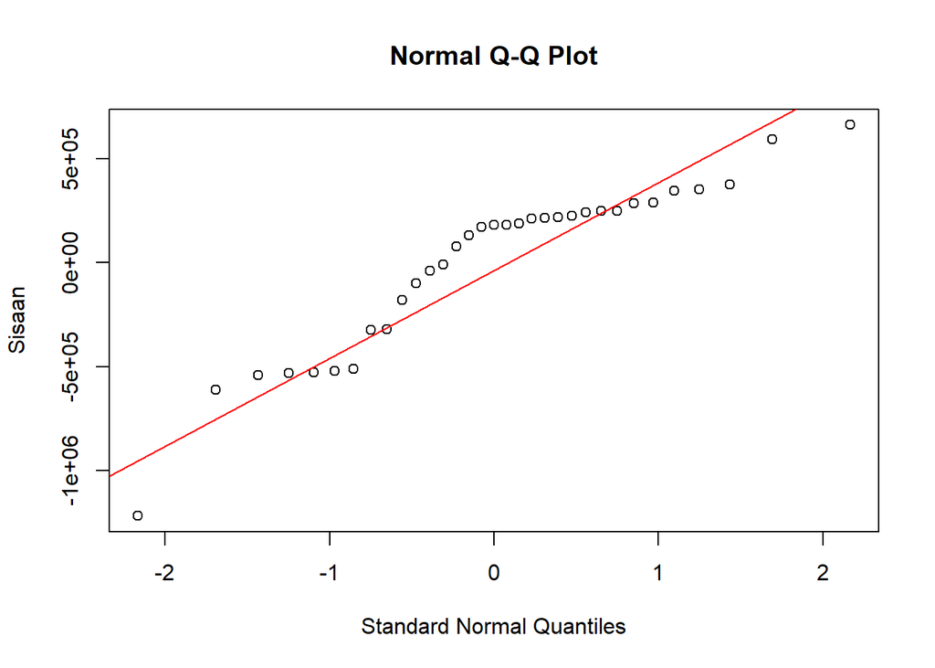

```r
model2<- lm(produksi.padi ~ luas.lahan+Penduduk, data = data)
resmodel2<-residuals(model2)
qqnorm(resmodel2, xlab="Standard Normal Quantiles",ylab = "Sisaan")
qqline(resmodel2,col=2)
```

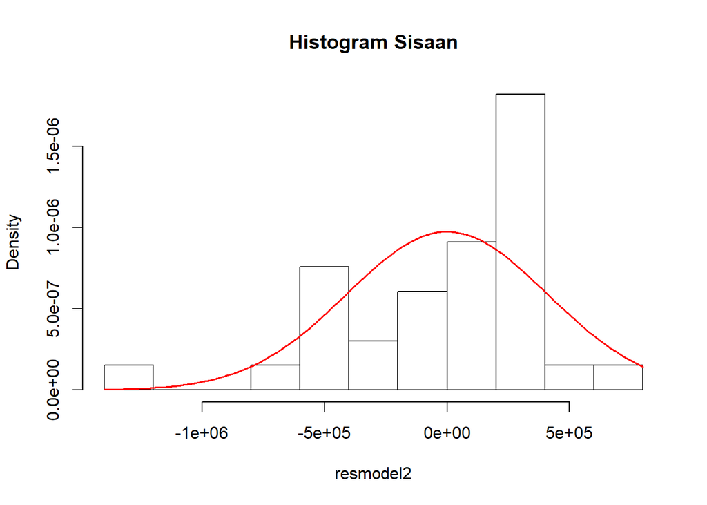

```r
hist(resmodel2, freq=FALSE, main="Histogram Sisaan")

curve(dnorm(x,mean=mean(resmodel2),sd=sd(resmodel2)),add=T,lwd=1.5,col="red")
```

```r
resmodel2<-residuals(model2)
ks.test(resmodel2, "pnorm")
```

```
##
##  One-sample Kolmogorov-Smirnov test
##
## data:  resmodel2
## D = 0.60606, p-value = 3.78e-12
## alternative hypothesis: two-sided
```

berdasarkan histogram dan normal qq-plot diatas menunjukkan bahwa sisaan tidak menyebar normal tetapi sisan menjulur ke kiri. selain itu, berdasarkan Uji Kolmogorov Smirnov P-value menunjukkan nilai sebesar 3.78e-12 lebih kecil dari $\alpha=0.05$ sehingga dapat dikatakan sisaan tidak menyebar normal.  
2. Mendeteksi Kehomogenan Ragam

```r
ncvTest(model2)
```

```
## Non-constant Variance Score Test
## Variance formula: ~ fitted.values
## Chisquare = 0.01488616    Df = 1     p = 0.902892
```

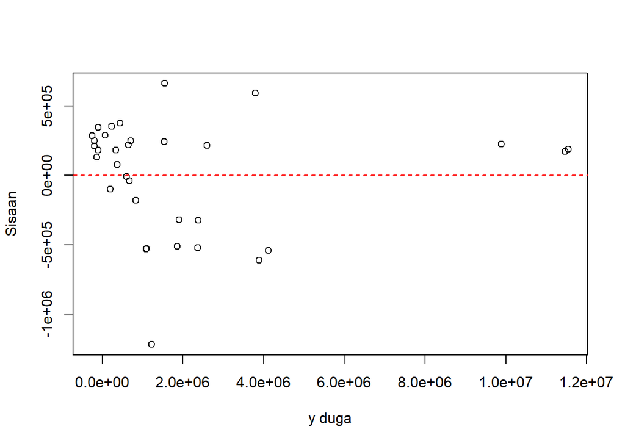

```r
pre<-predict(model2)
plot(pre,resmodel2,xlab="y duga",ylab="Sisaan")
abline(c(0,0),lty=2, col="red")
```

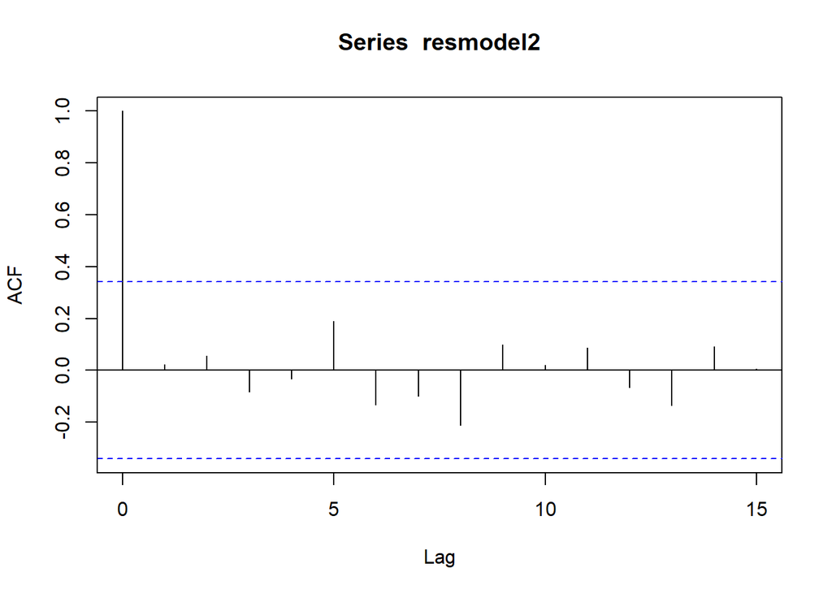

```r
acf(resmodel2)
```

```r
dwtest(model2, alt="two.sided")
```

```
##
##  Durbin-Watson test
##
## data:  model2
## DW = 1.9341, p-value = 0.7723
## alternative hypothesis: true autocorrelation is not 0
```

berdasarkan plot ACF sisaan diatas menunjukkan bahwa tidak terdapat sisaan yang saling berkorelasi. selain itu, pada uji Durbin Watson menunjukkan p-value sebesar 0.7723 lebih besar dari $\alpha=0.05$ sehingga dapat disimpulkan bahwa sisaan saling bebas.

# Penanganan Asumsi

sisaan model yang diperoleh tidak menyebar normal maka dilakukan penanganan dengan mentransformasi peubah respon. Metode Box-Cox dapat digunakan sebagai alternatif penentuan metode transformasi yang terbaik.

```r
bc <- boxcox(produksi.padi ~ luas.lahan+Penduduk, data = data)
```

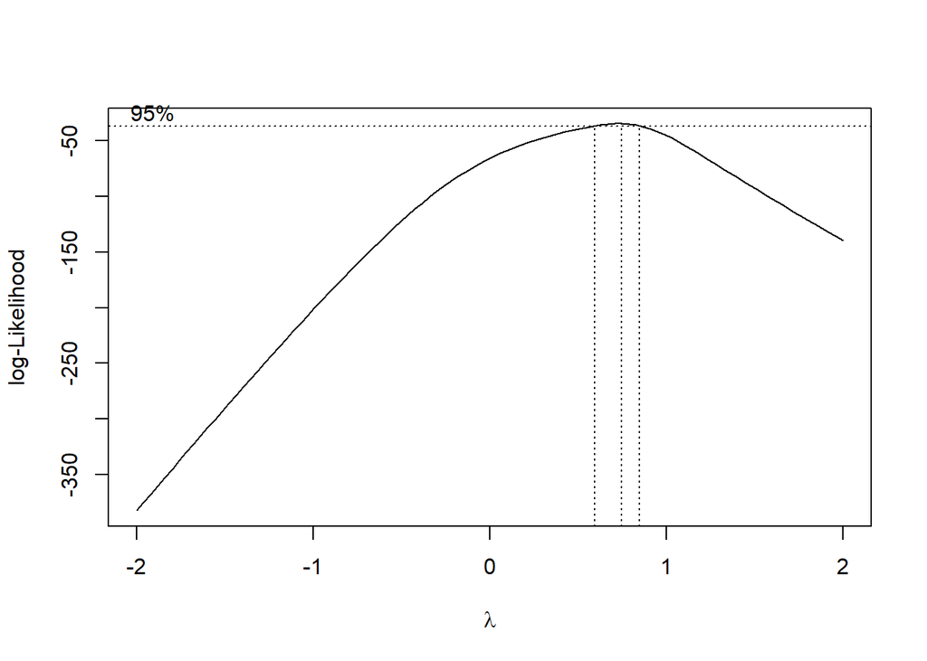

```r
lambda <- bc$x[which.max(bc$y)]
lambda
```

```
## [1] 0.7474747
```

```r
range(bc$x[bc$y > max(bc$y)-qchisq(0.95,1)/2])
```

```
## [1] 0.6262626 0.8282828
```

```r
lam<-bc$x
lik<-bc$y
boxcox <- cbind(lam, lik)
sorted_bc <- boxcox[order(-lik),]
head(sorted_bc, n = 10)
```

```
##             lam       lik
##  [1,] 0.7474747 -34.80538
##  [2,] 0.7070707 -34.85395
##  [3,] 0.7878788 -35.18905
##  [4,] 0.6666667 -35.26585
##  [5,] 0.6262626 -35.97596
##  [6,] 0.8282828 -36.07037
##  [7,] 0.5858586 -36.92103
##  [8,] 0.8686869 -37.47243
##  [9,] 0.5454545 -38.05061
## [10,] 0.5050505 -39.33315
```

# Model Hasil Transformasi

```r
model3<- lm(produksi.padi^(1/2) ~ luas.lahan+Penduduk, data = data)
summary(model3)
```

```
##
## Call:
## lm(formula = produksi.padi^(1/2) ~ luas.lahan + Penduduk, data = data)
##
## Residuals:
##    Min     1Q Median     3Q    Max
## -407.9 -190.4    7.1  145.9  430.5
##
## Coefficients:
##              Estimate Std. Error t value Pr(>|t|)
## (Intercept) 4.087e+02  5.246e+01   7.790 1.08e-08 ***
## luas.lahan  2.598e-03  2.914e-04   8.915 6.19e-10 ***
## Penduduk    1.056e-05  8.353e-06   1.264    0.216
## ---
## Signif. codes:  0 '***' 0.001 '**' 0.01 '*' 0.05 '.' 0.1 ' ' 1
##
## Residual standard error: 231.2 on 30 degrees of freedom
## Multiple R-squared:  0.937,  Adjusted R-squared:  0.9328
## F-statistic: 223.3 on 2 and 30 DF,  p-value: < 2.2e-16
```

Berdasarkan estimasi parameter model regresi hasil transformasi diperoleh bahwa peubah penduduk mempunyai p-value lebih besar dari $\alpha=0.05$ sehingga peubah penduduk tidak signifikan. selanjutnya dilakukan diagnostik model dengan memeriksa kembali semua asumsi.

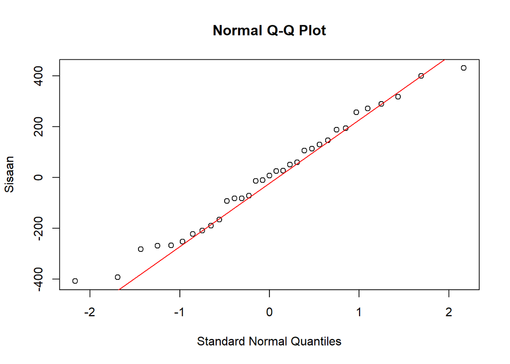

```r
resmodel3<-residuals(model3)
qqnorm(resmodel3, xlab="Standard Normal Quantiles",ylab = "Sisaan")
qqline(resmodel3,col=2)
```

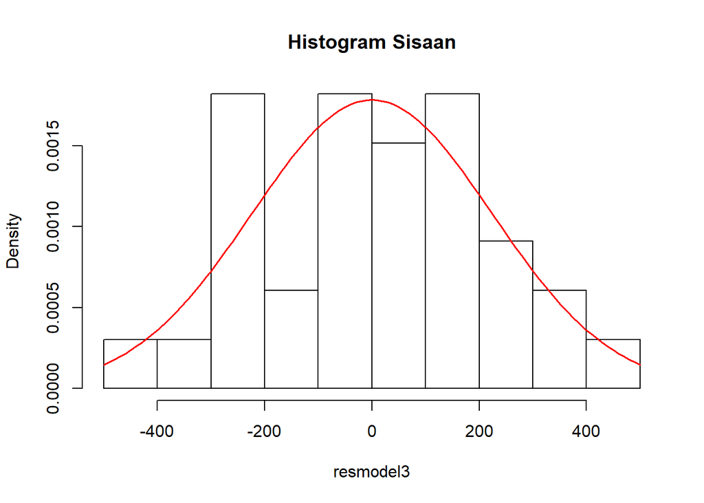

```r
hist(resmodel3, freq=FALSE, main="Histogram Sisaan")

curve(dnorm(x,mean=mean(resmodel3),sd=sd(resmodel3)),add=T,lwd=1.5,col="red")
```

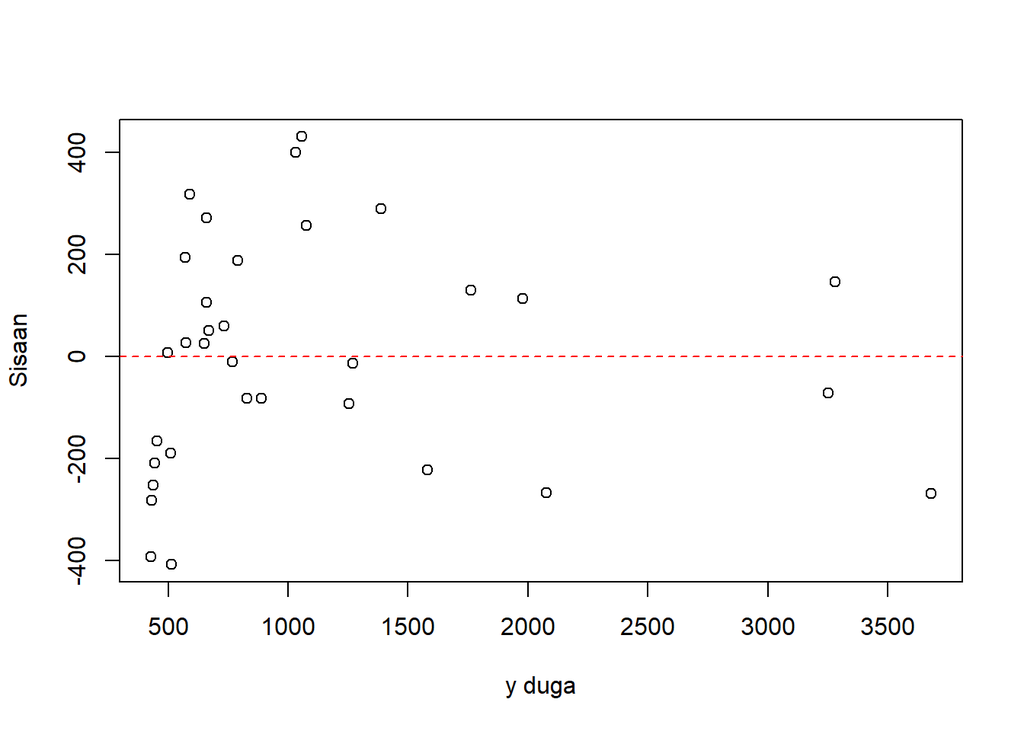

```r
pre3<-predict(model3)
plot(pre3,resmodel3,xlab="y duga",ylab="Sisaan")
abline(c(0,0),lty=2, col="red")
```

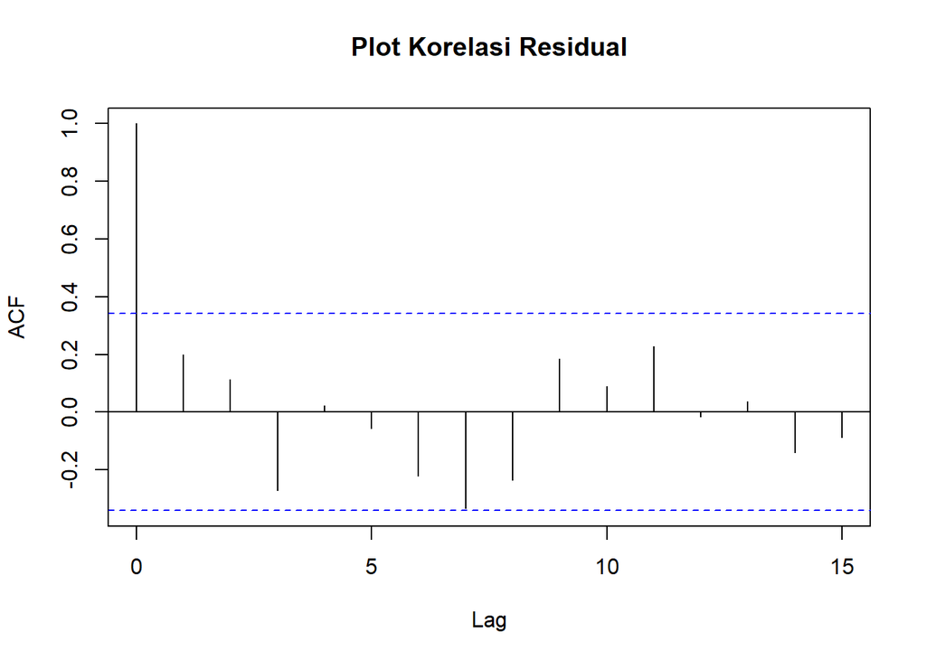

```r
resmodel3<-residuals(model3)
acf(resmodel3, main="Plot Korelasi Residual")
```

```r
durbinWatsonTest(model3)
```

```
##  lag Autocorrelation D-W Statistic p-value
##    1       0.1976233      1.582045   0.178
##  Alternative hypothesis: rho != 0
```

# Pencilan dan Amatan Berpengaruh

Amatan ekstrim terhadap peubah respon disebut dengan pencilan (outlier), sedangkan pada peubah penjelas disebut dengan laverage point. Amatan ekstim yang mempunyai pengaruh terhadap koefisien regresi disebut dengan amatan berpengaruh (Influential Observation).

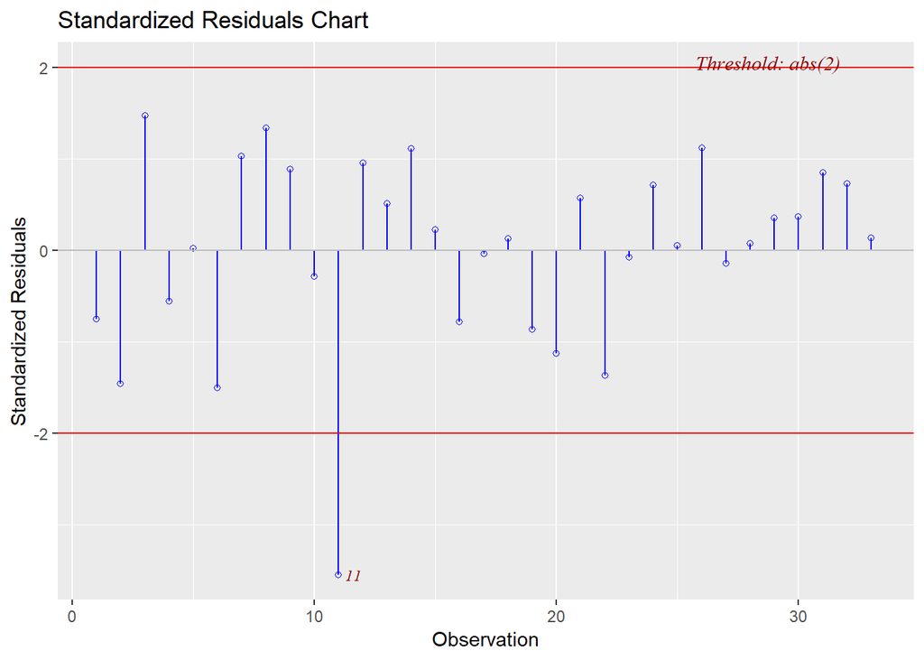

```r
#plot Standardized Residual
ols_plot_resid_stand(model)
```

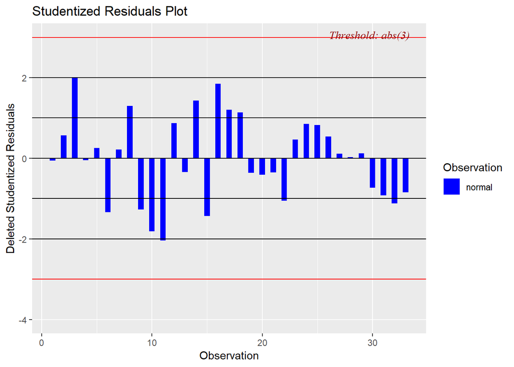

```r
#plot studentized Residual
ols_plot_resid_stud(model3)
```

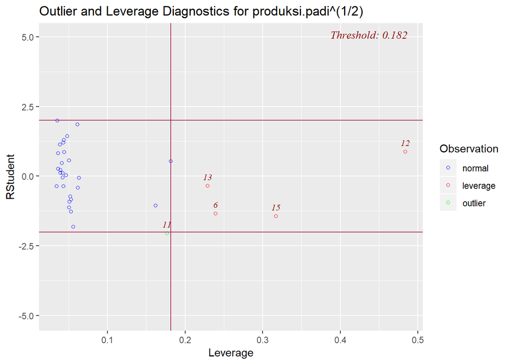

```r
##laverage
ols_plot_resid_lev(model3)
```

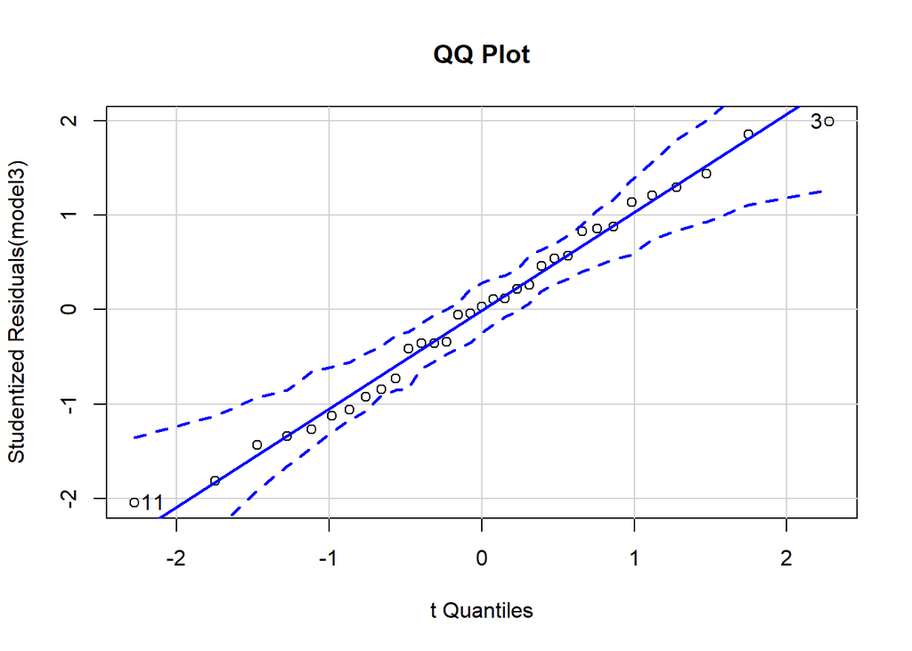

```
## [1]  3 11
```

```r
qqPlot(model3, main="QQ Plot")
```

```r
outlierTest(model3)
```

```
## No Studentized residuals with Bonferonni p < 0.05
## Largest |rstudent|:
##     rstudent unadjusted p-value Bonferonni p
## 11 -2.045201           0.050003           NA
```

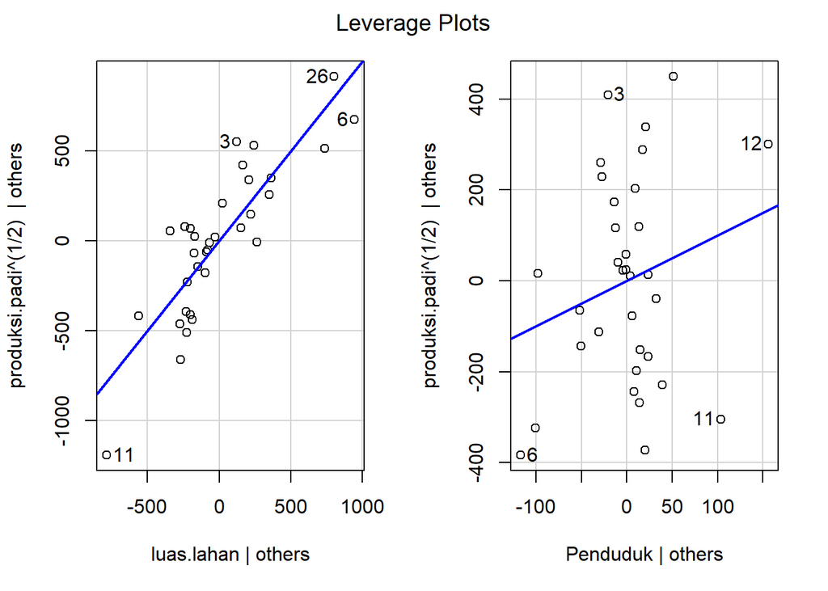

```r
leveragePlots(model3)
```

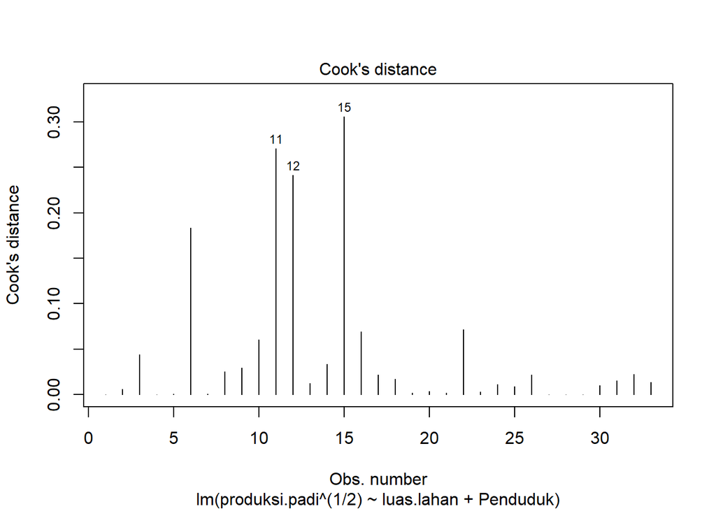

```r
# Amatan Berpengaruh
# Jarak Cook's
cutoff <- 4/((nrow(data)-length(model3$coefficients)-2))
plot(model3, which=4, cook.levels=cutoff)
```

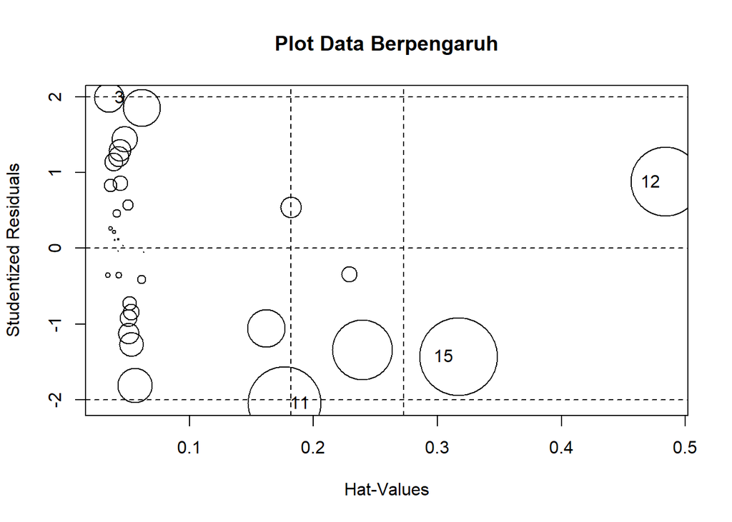

|  | StudRes | Hat | CookD |
| --- | --- | --- | --- |
| 3 | 1.9869967 | 0.03538445 | 0.04395633 |
| 11 | -2.0452009 | 0.17683515 | 0.27079465 |
| 12 | 0.8753619 | 0.48398190 | 0.24144333 |
| 15 | -1.4306092 | 0.31703328 | 0.30600792 |

```r
# Influence Plot
influencePlot(model3, main="Plot Data Berpengaruh" )
```